# (Bay Wheels Trip Data Exploration)

## Preliminary Wrangling

> This dataset contains data from Bike sharing service Bay Wheels fromerly known as Ford Go Bike. Data used for exploration can be found at https://s3.amazonaws.com/baywheels-data/index.html .

```python
# import all packages and set plots to be embedded inline
import numpy as np
import pandas as pd
import matplotlib.pyplot as plt
import seaborn as sns
%matplotlib inline

import os
import glob

import warnings
warnings.simplefilter("ignore")
```

I have manually downloaded and extracted all the data files into my local machine for the year 2019 from [here](https://s3.amazonaws.com/baywheels-data/index.html)

```python
#Merge all the 2019 months data files into a single master file for year 2019

file_name = 'baywheels_tripdata_2019.csv'
if not os.path.isfile(file_name):
    multi = []
    folder_name = 'Data'
    for cs in glob.glob(os.path.join(folder_name, '*tripdata.csv')):
        multi.append(pd.read_csv(cs))
    single = pd.concat(multi, ignore_index = True)
    single.to_csv(file_name, index = False, sort=True)
#single.head()
```

```python
#reading from the master data file
df = pd.read_csv(file_name)
```

```python
df.head()
```

|  | bike_id | bike_share_for_all_trip | duration_sec | end_station_id | end_station_latitude | end_station_longitude | end_station_name | end_time | rental_access_method | start_station_id | start_station_latitude | start_station_longitude | start_station_name | start_time | user_type |
| --- | --- | --- | --- | --- | --- | --- | --- | --- | --- | --- | --- | --- | --- | --- | --- |
| 0 | 4861 | No | 80825 | 196.0 | 37.808894 | -122.256460 | Grand Ave at Perkins St | 2019-02-01 16:24:49.8640 | NaN | 229.0 | 37.775745 | -122.213037 | Foothill Blvd at 42nd Ave | 2019-01-31 17:57:44.6130 | Subscriber |
| 1 | 5506 | No | 65900 | 134.0 | 37.752428 | -122.420628 | Valencia St at 24th St | 2019-02-01 15:16:54.1730 | NaN | 4.0 | 37.785881 | -122.408915 | Cyril Magnin St at Ellis St | 2019-01-31 20:58:33.8860 | Subscriber |
| 2 | 2717 | No | 62633 | 157.0 | 37.846784 | -122.291376 | 65th St at Hollis St | 2019-02-01 11:30:46.5300 | NaN | 245.0 | 37.870139 | -122.268422 | Downtown Berkeley BART | 2019-01-31 18:06:52.9240 | Customer |
| 3 | 4557 | No | 44680 | 53.0 | 37.775946 | -122.437777 | Grove St at Divisadero | 2019-02-01 08:10:50.3180 | NaN | 85.0 | 37.770083 | -122.429156 | Church St at Duboce Ave | 2019-01-31 19:46:09.7190 | Customer |
| 4 | 2100 | No | 60709 | 28.0 | 37.787168 | -122.388098 | The Embarcadero at Bryant St | 2019-02-01 07:10:51.0650 | NaN | 16.0 | 37.794130 | -122.394430 | Steuart St at Market St | 2019-01-31 14:19:01.5410 | Customer |

```python
df.tail()
```

|  | bike_id | bike_share_for_all_trip | duration_sec | end_station_id | end_station_latitude | end_station_longitude | end_station_name | end_time | rental_access_method | start_station_id | start_station_latitude | start_station_longitude | start_station_name | start_time | user_type |
| --- | --- | --- | --- | --- | --- | --- | --- | --- | --- | --- | --- | --- | --- | --- | --- |
| 2506978 | 719651 | NaN | 731 | NaN | 37.807573 | -122.421681 | NaN | 2019-12-28 18:49:40 | app | NaN | 37.809731 | -122.409855 | NaN | 2019-12-28 18:37:29 | Subscriber |
| 2506979 | 655411 | NaN | 748 | NaN | 37.807558 | -122.421638 | NaN | 2019-12-28 18:49:53 | app | NaN | 37.809768 | -122.409797 | NaN | 2019-12-28 18:37:24 | Subscriber |
| 2506980 | 936881 | NaN | 1044 | NaN | 37.807225 | -122.408850 | NaN | 2019-12-26 14:43:02 | app | NaN | 37.810183 | -122.410271 | NaN | 2019-12-26 14:25:37 | Subscriber |
| 2506981 | 397539 | NaN | 326 | NaN | 37.803143 | -122.414373 | NaN | 2019-12-30 20:41:09 | app | NaN | 37.810471 | -122.417386 | NaN | 2019-12-30 20:35:43 | Subscriber |
| 2506982 | 662304 | NaN | 4023 | NaN | 37.810970 | -122.418054 | NaN | 2019-12-31 20:33:52 | app | NaN | 37.811042 | -122.418149 | NaN | 2019-12-31 19:26:48 | Subscriber |

```python
df.info()
```

```
<class 'pandas.core.frame.DataFrame'>
RangeIndex: 2506983 entries, 0 to 2506982
Data columns (total 15 columns):
bike_id                    int64
bike_share_for_all_trip    object
duration_sec               int64
end_station_id             float64
end_station_latitude       float64
end_station_longitude      float64
end_station_name           object
end_time                   object
rental_access_method       object
start_station_id           float64
start_station_latitude     float64
start_station_longitude    float64
start_station_name         object
start_time                 object
user_type                  object
dtypes: float64(6), int64(2), object(7)
memory usage: 286.9+ MB
```

```python
df.describe()
```

|  | bike_id | duration_sec | end_station_id | end_station_latitude | end_station_longitude | start_station_id | start_station_latitude | start_station_longitude |
| --- | --- | --- | --- | --- | --- | --- | --- | --- |
| count | 2.506983e+06 | 2.506983e+06 | 2.424081e+06 | 2.506983e+06 | 2.506983e+06 | 2.426249e+06 | 2.506983e+06 | 2.506983e+06 |
| mean | 2.789833e+04 | 8.076483e+02 | 1.427044e+02 | 3.776422e+01 | -1.223459e+02 | 1.465047e+02 | 3.776506e+01 | -1.223499e+02 |
| std | 1.146067e+05 | 1.974714e+03 | 1.214296e+02 | 2.392885e-01 | 7.080417e-01 | 1.223171e+02 | 1.363698e-01 | 3.089648e-01 |
| min | 4.000000e+00 | 6.000000e+01 | 3.000000e+00 | 0.000000e+00 | -1.225143e+02 | 3.000000e+00 | 0.000000e+00 | -1.225143e+02 |
| 25% | 1.952000e+03 | 3.590000e+02 | 4.300000e+01 | 3.777003e+01 | -1.224117e+02 | 4.700000e+01 | 3.776931e+01 | -1.224130e+02 |
| 50% | 4.420000e+03 | 5.710000e+02 | 1.010000e+02 | 3.778076e+01 | -1.223981e+02 | 1.050000e+02 | 3.778053e+01 | -1.223983e+02 |
| 75% | 9.682000e+03 | 8.870000e+02 | 2.390000e+02 | 3.779587e+01 | -1.222934e+02 | 2.430000e+02 | 3.779539e+01 | -1.222914e+02 |
| max | 9.999410e+05 | 9.121100e+05 | 4.980000e+02 | 4.551000e+01 | 0.000000e+00 | 4.980000e+02 | 4.551000e+01 | 0.000000e+00 |

```python
df.duplicated().any()
```

```
False
```

### What is the structure of your dataset?

> The dataset has total of 2506983 entries and 15 columns(features) with information like user id, bike id, location co-ordinates, name, start time , end time of the trip, rental method etc.

### What is/are the main feature(s) of interest in your dataset?

> The intersting features will be :

> ```
> - The duration of the trip. <br>
> - User types.<br>
> - Time when the trip was taken(day of the week).<br>
> ```

### What features in the dataset do you think will help support your investigation into your feature(s) of interest?

> Following features will be most helpful for my investigation :  
> duration_sec, user_type, start_time, end_time

### Before starting our exploration lets look into our data and see how we can use it for our investigation

the data that we have downloaded from bucket has two names forgobike and baywheels as former name was rebranded into Bay wheels after April 2019. Lets look into what has changed in data during that period.

```python
df.head()
```

|  | bike_id | bike_share_for_all_trip | duration_sec | end_station_id | end_station_latitude | end_station_longitude | end_station_name | end_time | rental_access_method | start_station_id | start_station_latitude | start_station_longitude | start_station_name | start_time | user_type |
| --- | --- | --- | --- | --- | --- | --- | --- | --- | --- | --- | --- | --- | --- | --- | --- |
| 0 | 4861 | No | 80825 | 196.0 | 37.808894 | -122.256460 | Grand Ave at Perkins St | 2019-02-01 16:24:49.8640 | NaN | 229.0 | 37.775745 | -122.213037 | Foothill Blvd at 42nd Ave | 2019-01-31 17:57:44.6130 | Subscriber |
| 1 | 5506 | No | 65900 | 134.0 | 37.752428 | -122.420628 | Valencia St at 24th St | 2019-02-01 15:16:54.1730 | NaN | 4.0 | 37.785881 | -122.408915 | Cyril Magnin St at Ellis St | 2019-01-31 20:58:33.8860 | Subscriber |
| 2 | 2717 | No | 62633 | 157.0 | 37.846784 | -122.291376 | 65th St at Hollis St | 2019-02-01 11:30:46.5300 | NaN | 245.0 | 37.870139 | -122.268422 | Downtown Berkeley BART | 2019-01-31 18:06:52.9240 | Customer |
| 3 | 4557 | No | 44680 | 53.0 | 37.775946 | -122.437777 | Grove St at Divisadero | 2019-02-01 08:10:50.3180 | NaN | 85.0 | 37.770083 | -122.429156 | Church St at Duboce Ave | 2019-01-31 19:46:09.7190 | Customer |
| 4 | 2100 | No | 60709 | 28.0 | 37.787168 | -122.388098 | The Embarcadero at Bryant St | 2019-02-01 07:10:51.0650 | NaN | 16.0 | 37.794130 | -122.394430 | Steuart St at Market St | 2019-01-31 14:19:01.5410 | Customer |

```python
df['duration_sec'].sort_values()
```

```
1421086        60
1449824        60
1415832        60
1415886        60
1486204        60
            ...
1741971     86114
644460      86114
1265667     86217
2385537     86230
2481276    912110
Name: duration_sec, Length: 2506983, dtype: int64
```

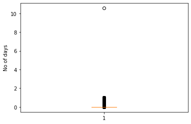

```python
plt.boxplot(df['duration_sec']/(3600*24));
plt.ylabel('No of days')
```

except for the last entry of 912110 secs which converts to roughly 10 days all other entries have duration less than 1 day

```python
df['start_time'] = pd.to_datetime(df['start_time'])
```

```python
df['end_time'] = pd.to_datetime(df['end_time'])
```

```python
df['day'] = df.apply(lambda x: x.start_time.day_name(), axis = 1)
```

```python
df['month'] = df.apply(lambda x: x.start_time.month_name(), axis = 1)
```

```python
df.head()
```

|  | bike_id | bike_share_for_all_trip | duration_sec | end_station_id | end_station_latitude | end_station_longitude | end_station_name | end_time | rental_access_method | start_station_id | start_station_latitude | start_station_longitude | start_station_name | start_time | user_type | day | month |
| --- | --- | --- | --- | --- | --- | --- | --- | --- | --- | --- | --- | --- | --- | --- | --- | --- | --- |
| 0 | 4861 | No | 80825 | 196.0 | 37.808894 | -122.256460 | Grand Ave at Perkins St | 2019-02-01 16:24:49.864 | NaN | 229.0 | 37.775745 | -122.213037 | Foothill Blvd at 42nd Ave | 2019-01-31 17:57:44.613 | Subscriber | Thursday | January |
| 1 | 5506 | No | 65900 | 134.0 | 37.752428 | -122.420628 | Valencia St at 24th St | 2019-02-01 15:16:54.173 | NaN | 4.0 | 37.785881 | -122.408915 | Cyril Magnin St at Ellis St | 2019-01-31 20:58:33.886 | Subscriber | Thursday | January |
| 2 | 2717 | No | 62633 | 157.0 | 37.846784 | -122.291376 | 65th St at Hollis St | 2019-02-01 11:30:46.530 | NaN | 245.0 | 37.870139 | -122.268422 | Downtown Berkeley BART | 2019-01-31 18:06:52.924 | Customer | Thursday | January |
| 3 | 4557 | No | 44680 | 53.0 | 37.775946 | -122.437777 | Grove St at Divisadero | 2019-02-01 08:10:50.318 | NaN | 85.0 | 37.770083 | -122.429156 | Church St at Duboce Ave | 2019-01-31 19:46:09.719 | Customer | Thursday | January |
| 4 | 2100 | No | 60709 | 28.0 | 37.787168 | -122.388098 | The Embarcadero at Bryant St | 2019-02-01 07:10:51.065 | NaN | 16.0 | 37.794130 | -122.394430 | Steuart St at Market St | 2019-01-31 14:19:01.541 | Customer | Thursday | January |

```python
df[df.month == 'April']
```

|  | bike_id | bike_share_for_all_trip | duration_sec | end_station_id | end_station_latitude | end_station_longitude | end_station_name | end_time | rental_access_method | start_station_id | start_station_latitude | start_station_longitude | start_station_name | start_time | user_type | day | month |
| --- | --- | --- | --- | --- | --- | --- | --- | --- | --- | --- | --- | --- | --- | --- | --- | --- | --- |
| 631793 | 2749 | No | 50305 | 324.0 | 37.788300 | -122.408531 | Union Square (Powell St at Post St) | 2019-05-01 12:32:20.454 | NaN | 368.0 | 37.785434 | -122.419622 | Myrtle St at Polk St | 2019-04-30 22:33:55.155 | Subscriber | Tuesday | April |
| 631794 | 2608 | No | 53725 | 241.0 | 37.852477 | -122.270213 | Ashby BART Station | 2019-05-01 11:39:06.917 | NaN | 246.0 | 37.869060 | -122.270556 | Berkeley Civic Center | 2019-04-30 20:43:41.632 | Customer | Tuesday | April |
| 631795 | 258 | No | 78072 | 64.0 | 37.776754 | -122.399018 | 5th St at Brannan St | 2019-05-01 08:13:58.975 | NaN | 64.0 | 37.776754 | -122.399018 | 5th St at Brannan St | 2019-04-30 10:32:46.489 | Subscriber | Tuesday | April |
| 631796 | 1974 | No | 78969 | 89.0 | 37.769218 | -122.407646 | Division St at Potrero Ave | 2019-05-01 07:57:01.262 | NaN | 67.0 | 37.776639 | -122.395526 | San Francisco Caltrain Station 2 (Townsend St... | 2019-04-30 10:00:51.550 | Subscriber | Tuesday | April |
| 631797 | 877 | No | 1128 | 5.0 | 37.783899 | -122.408445 | Powell St BART Station (Market St at 5th St) | 2019-05-01 00:17:53.091 | NaN | 124.0 | 37.760447 | -122.410807 | 19th St at Florida St | 2019-04-30 23:59:04.739 | Subscriber | Tuesday | April |
| ... | ... | ... | ... | ... | ... | ... | ... | ... | ... | ... | ... | ... | ... | ... | ... | ... | ... |
| 870899 | 6430 | No | 184 | 132.0 | 37.751819 | -122.426614 | 24th St at Chattanooga St | 2019-04-01 00:12:22.517 | NaN | 133.0 | 37.755213 | -122.420975 | Valencia St at 22nd St | 2019-04-01 00:09:17.566 | Subscriber | Monday | April |
| 870900 | 4972 | Yes | 539 | 77.0 | 37.773507 | -122.416040 | 11th St at Natoma St | 2019-04-01 00:12:02.067 | NaN | 78.0 | 37.773717 | -122.411647 | Folsom St at 9th St | 2019-04-01 00:03:02.573 | Subscriber | Monday | April |
| 870901 | 3415 | Yes | 292 | 269.0 | 37.862320 | -122.258801 | Telegraph Ave at Carleton St | 2019-04-01 00:10:56.985 | NaN | 243.0 | 37.869360 | -122.254337 | Bancroft Way at College Ave | 2019-04-01 00:06:04.237 | Subscriber | Monday | April |
| 870902 | 5018 | Yes | 471 | 43.0 | 37.778768 | -122.415929 | San Francisco Public Library (Grove St at Hyde... | 2019-04-01 00:09:29.965 | NaN | 370.0 | 37.787327 | -122.413278 | Jones St at Post St | 2019-04-01 00:01:38.411 | Subscriber | Monday | April |
| 870903 | 5956 | No | 356 | 371.0 | 37.802746 | -122.413579 | Lombard St at Columbus Ave | 2019-04-01 00:06:25.065 | NaN | 14.0 | 37.795001 | -122.399970 | Clay St at Battery St | 2019-04-01 00:00:28.729 | Subscriber | Monday | April |

239111 rows × 17 columns

```python
df[df.month == 'June']
```

|  | bike_id | bike_share_for_all_trip | duration_sec | end_station_id | end_station_latitude | end_station_longitude | end_station_name | end_time | rental_access_method | start_station_id | start_station_latitude | start_station_longitude | start_station_name | start_time | user_type | day | month |
| --- | --- | --- | --- | --- | --- | --- | --- | --- | --- | --- | --- | --- | --- | --- | --- | --- | --- |
| 1053067 | 1502 | No | 81695 | 56.0 | 37.773414 | -122.427317 | Koshland Park | 2019-07-01 16:57:45.592 | NaN | 109.0 | 37.763316 | -122.421904 | 17th St at Valencia St | 2019-06-30 18:16:09.773 | Subscriber | Sunday | June |
| 1053068 | 2526 | No | 74260 | 101.0 | 37.767079 | -122.407359 | 15th St at Potrero Ave | 2019-07-01 14:47:36.681 | NaN | 50.0 | 37.780526 | -122.390288 | 2nd St at Townsend St | 2019-06-30 18:09:55.830 | Customer | Sunday | June |
| 1053069 | 2427 | No | 59603 | 30.0 | 37.776598 | -122.395282 | San Francisco Caltrain (Townsend St at 4th St) | 2019-07-01 08:13:54.349 | NaN | 23.0 | 37.791464 | -122.391034 | The Embarcadero at Steuart St | 2019-06-30 15:40:31.038 | Subscriber | Sunday | June |
| 1053070 | 1261 | No | 67932 | 248.0 | 37.855956 | -122.259795 | Telegraph Ave at Ashby Ave | 2019-07-01 07:42:00.543 | NaN | 169.0 | 37.846516 | -122.265304 | Bushrod Park | 2019-06-30 12:49:47.781 | Customer | Sunday | June |
| 1053071 | 1070 | No | 48894 | 30.0 | 37.776598 | -122.395282 | San Francisco Caltrain (Townsend St at 4th St) | 2019-07-01 06:55:54.996 | NaN | 15.0 | 37.795392 | -122.394203 | San Francisco Ferry Building (Harry Bridges Pl... | 2019-06-30 17:21:00.055 | Customer | Sunday | June |
| ... | ... | ... | ... | ... | ... | ... | ... | ... | ... | ... | ... | ... | ... | ... | ... | ... | ... |
| 1244834 | 309118 | NaN | 1453 | NaN | 37.396962 | -121.941089 | NaN | 2019-06-23 19:04:24.000 | app | NaN | 37.416979 | -121.956381 | NaN | 2019-06-23 18:40:11.000 | Customer | Sunday | June |
| 1244835 | 186867 | NaN | 1674 | NaN | 37.406156 | -121.941510 | NaN | 2019-06-24 22:35:32.000 | app | NaN | 37.417026 | -121.954276 | NaN | 2019-06-24 22:07:37.000 | Customer | Monday | June |
| 1244836 | 663918 | NaN | 672 | NaN | 37.413978 | -121.940664 | NaN | 2019-06-26 16:19:04.000 | clipper | NaN | 37.417792 | -121.955901 | NaN | 2019-06-26 16:07:51.000 | Subscriber | Wednesday | June |
| 1244837 | 322735 | NaN | 1385 | NaN | 37.405492 | -121.941507 | NaN | 2019-06-26 22:57:53.000 | app | NaN | 37.417983 | -121.955682 | NaN | 2019-06-26 22:34:47.000 | Customer | Wednesday | June |
| 1244838 | 108375 | NaN | 794 | NaN | 37.405155 | -121.933065 | NaN | 2019-06-24 20:48:02.000 | app | NaN | 37.418230 | -121.955282 | NaN | 2019-06-24 20:34:47.000 | Customer | Monday | June |

191772 rows × 17 columns

From above information we can see that bike_share_for_all_trip column data is available till month of June and rental_access_method data is available from the month of June. We dont know why excatly they decided to make this change in there stored data so we will not use both of those coluns in our exploration.

```python
df.drop(columns = ['bike_share_for_all_trip','rental_access_method'], axis=1, inplace = True)
```

```python
df.info()
```

```
<class 'pandas.core.frame.DataFrame'>
RangeIndex: 2506983 entries, 0 to 2506982
Data columns (total 15 columns):
bike_id                    int64
duration_sec               int64
end_station_id             float64
end_station_latitude       float64
end_station_longitude      float64
end_station_name           object
end_time                   datetime64[ns]
start_station_id           float64
start_station_latitude     float64
start_station_longitude    float64
start_station_name         object
start_time                 datetime64[ns]
user_type                  object
day                        object
month                      object
dtypes: datetime64[ns](2), float64(6), int64(2), object(5)
memory usage: 286.9+ MB
```

## Univariate Exploration

### Number of rides taken each month

```python
df.bike_id.isnull().any()
```

```
False
```

```python
per_month = df.groupby('month')['month','bike_id'].count().sort_values('bike_id', ascending=False)
per_month
```

| month | month | bike_id |
| --- | --- | --- |
| July | 258102 | 258102 |
| March | 256299 | 256299 |
| October | 239895 | 239895 |
| April | 239111 | 239111 |
| September | 217986 | 217986 |
| August | 210563 | 210563 |
| January | 192082 | 192082 |
| June | 191772 | 191772 |
| November | 185496 | 185496 |
| February | 183412 | 183412 |
| May | 182163 | 182163 |
| December | 150102 | 150102 |

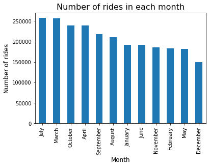

```python
per_month.month.plot(kind='bar');
plt.xlabel('Month', fontsize=12)
plt.ylabel('Number of rides', fontsize=12)
plt.title('Number of rides in each month', fontsize=16)
```

So most rides were taken in the month of July and March and the least in December.

### Number of rides taken by day of the week

```python
per_day = df.groupby('day')['day','bike_id'].count().sort_values('bike_id', ascending=False)
per_day
```

| day | day | bike_id |
| --- | --- | --- |
| Tuesday | 427640 | 427640 |
| Thursday | 424474 | 424474 |
| Wednesday | 414448 | 414448 |
| Friday | 397284 | 397284 |
| Monday | 396463 | 396463 |
| Saturday | 234370 | 234370 |
| Sunday | 212304 | 212304 |

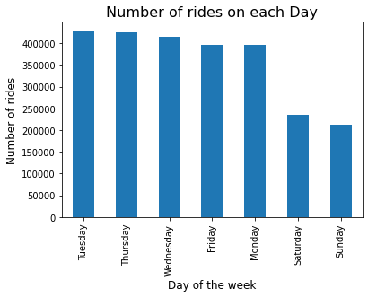

```python
per_day.day.plot(kind='bar')
plt.xlabel('Day of the week', fontsize=12)
plt.ylabel('Number of rides', fontsize=12)
plt.title('Number of rides on each Day', fontsize=16)
```

We can se that people were using the rental service mostly on the week days (almost double than the weekends) It might have something to do with their commuting to work.

We will look into user type and day of the week trips later more in bivariate exploration to confirm the same.

### Now lets look into types of user taking the rides

```python
user_type = df.groupby('user_type')['user_type','bike_id'].count().sort_values('bike_id', ascending=False)
user_type
```

| user_type | user_type | bike_id |
| --- | --- | --- |
| Subscriber | 2021166 | 2021166 |
| Customer | 485817 | 485817 |

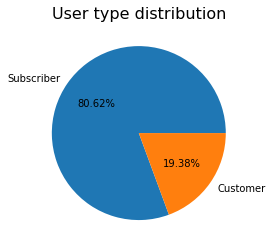

```python
user_type.user_type.plot(kind='pie', autopct='%1.2f%%');

plt.title('User type distribution', fontsize=16)
plt.ylabel(None)
```

So around 80% of the user base using the bikes is subscriber of the Bay wheels rental service.

### Average durations for which the ride were taken

before finding the average duration of rides lets remove our outlier that is the rider with duartion value of 912110

```python
df[df['duration_sec'] == df['duration_sec'].max()]
```

|  | bike_id | duration_sec | end_station_id | end_station_latitude | end_station_longitude | end_station_name | end_time | start_station_id | start_station_latitude | start_station_longitude | start_station_name | start_time | user_type | day | month |
| --- | --- | --- | --- | --- | --- | --- | --- | --- | --- | --- | --- | --- | --- | --- | --- |
| 2481276 | 614329 | 912110 | NaN | 37.327656 | -121.868598 | NaN | 2019-12-30 12:37:26 | NaN | 37.323757 | -121.878614 | NaN | 2019-12-19 23:15:36 | Customer | Thursday | December |

```python
df.loc[2481276]
```

```
bike_id                                 614329
duration_sec                            912110
end_station_id                             NaN
end_station_latitude                   37.3277
end_station_longitude                 -121.869
end_station_name                           NaN
end_time                   2019-12-30 12:37:26
start_station_id                           NaN
start_station_latitude                 37.3238
start_station_longitude               -121.879
start_station_name                         NaN
start_time                 2019-12-19 23:15:36
user_type                             Customer
day                                   Thursday
month                                 December
Name: 2481276, dtype: object
```

```python
df.drop(2481276, inplace = True,axis=0)
```

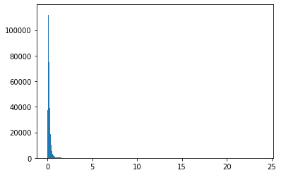

```python
bin_edge = np.arange(0,df['duration_sec'].max()/3600, .01 )
plt.hist(df['duration_sec']/3600, bins=bin_edge);
```

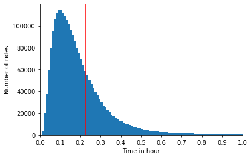

```python
bin_edge = np.arange(0,df['duration_sec'].max()/3600, .01 )
plt.hist(df['duration_sec']/3600, bins=bin_edge);
plt.xlim(0,1)
plt.xticks([0,.1,.2,.3,.4,.5,.6,.7,.8,.9,1])
plt.xlabel('Time in hour')
plt.ylabel('Number of rides')
plt.axvline(df['duration_sec'].mean()/3600, color='r')
```

So most of the rides were of short duration (less than 30 mins).

```python
start_stn = pd.DataFrame(df.start_station_name.value_counts())
```

```python
end_stn = pd.DataFrame(df.end_station_name.value_counts())
```

```python
start_stn.head()
```

|  | start_station_name |
| --- | --- |
| Market St at 10th St | 45058 |
| Berry St at 4th St | 42962 |
| San Francisco Caltrain (Townsend St at 4th St) | 40302 |
| San Francisco Ferry Building (Harry Bridges Plaza) | 39016 |
| San Francisco Caltrain Station 2 (Townsend St at 4th St) | 36576 |

```python
end_stn.head()
```

|  | end_station_name |
| --- | --- |
| San Francisco Caltrain Station 2 (Townsend St at 4th St) | 52146 |
| San Francisco Caltrain (Townsend St at 4th St) | 50943 |
| San Francisco Ferry Building (Harry Bridges Plaza) | 48180 |
| Montgomery St BART Station (Market St at 2nd St) | 47886 |
| Market St at 10th St | 44284 |

```python
stn = pd.DataFrame(start_stn['start_station_name'] + end_stn['end_station_name'])
stn.index.name = 'Name'
stn = stn.head(10).sort_values([0])
```

```python
end_stn.info()
```

```
<class 'pandas.core.frame.DataFrame'>
Index: 446 entries, San Francisco Caltrain Station 2  (Townsend St at 4th St) to Emeryville Depot
Data columns (total 1 columns):
end_station_name    446 non-null int64
dtypes: int64(1)
memory usage: 27.0+ KB
```

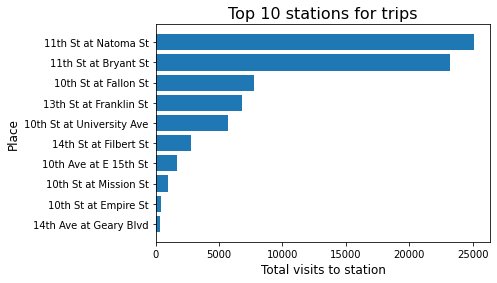

```python
plt.barh(stn.index,stn[0]);
plt.xlabel('Total visits to station', fontsize=12);
plt.ylabel('Place', fontsize=12);
plt.title('Top 10 stations for trips', fontsize=16);
```

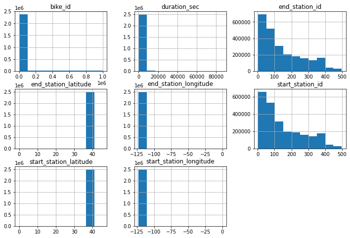

```python
df.hist(figsize = [12,8]);
```

### Discuss the distribution(s) of your variable(s) of interest. Were there any unusual points? Did you need to perform any transformations?

> So from above we can say that. major userbase of the bay wheels service are subscibed to them(80%). Around 95% of the rides are of time less than half hour. Most travels are during the weekdays mostly for the comuting to work.

### Of the features you investigated, were there any unusual distributions? Did you perform any operations on the data to tidy, adjust, or change the form of the data? If so, why did you do this?

> I wanted data by month and day basis so I added those columns and removed the columns 'bike_share_for_all_trip','rental_access_method' as data for those features is not present for entire 2019 year. Also I droped the row with max duration seconds as there was only 1 record with rental duration of 10 days and others were very small compared to that around 10-20 mins. So I considered that record as outlier for our explorartion.

## Bivariate Exploration

### Lets now look at the relationship between day of the week and type of user.

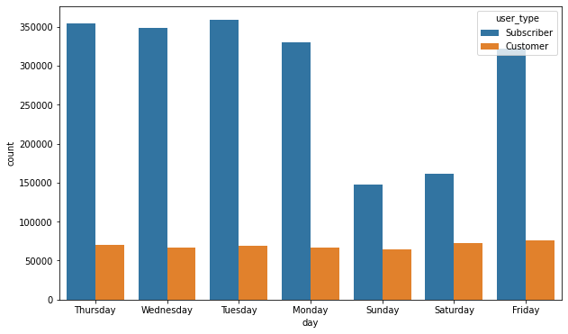

```python
plt.figure(figsize=(10,6))
sns.countplot(data = df, x ='day', hue = "user_type");
```

So our graph asuggest that there is a possibility that most of the subscribers are using rides as their commute to work vehicle. That explains the drop in count for subscribers on Saturday and Sunday.

### How will be the realtionship by the month for the same.

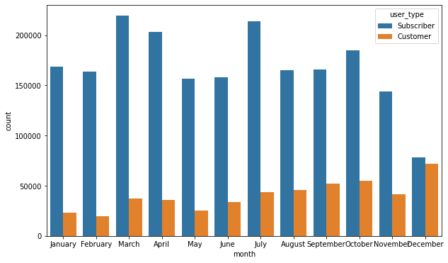

```python
plt.figure(figsize=(10,6))
sns.countplot(data = df, x ='month', hue = "user_type");
```

Here we cam observe one interesting fact that for the month of december the count of subscribers using rides is least and that of the normal customer is the most. This might be due to christmas holidays?

```python
df_dec = df[df.month == 'December']
```

```python
df_dec['date'] = df_dec.apply(lambda x: x.start_time.date(), axis = 1)
```

```python
df_dec.info()
```

```
<class 'pandas.core.frame.DataFrame'>
Int64Index: 150101 entries, 2356881 to 2506982
Data columns (total 16 columns):
bike_id                    150101 non-null int64
duration_sec               150101 non-null int64
end_station_id             128755 non-null float64
end_station_latitude       150101 non-null float64
end_station_longitude      150101 non-null float64
end_station_name           128757 non-null object
end_time                   150101 non-null datetime64[ns]
start_station_id           129083 non-null float64
start_station_latitude     150101 non-null float64
start_station_longitude    150101 non-null float64
start_station_name         129087 non-null object
start_time                 150101 non-null datetime64[ns]
user_type                  150101 non-null object
day                        150101 non-null object
month                      150101 non-null object
date                       150101 non-null object
dtypes: datetime64[ns](2), float64(6), int64(2), object(6)
memory usage: 19.5+ MB
```

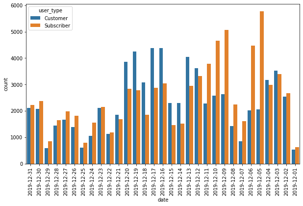

```python
plt.figure(figsize=(10,6))
sns.countplot(data = df_dec, x ='date', hue = "user_type");
plt.xticks(rotation=90);
```

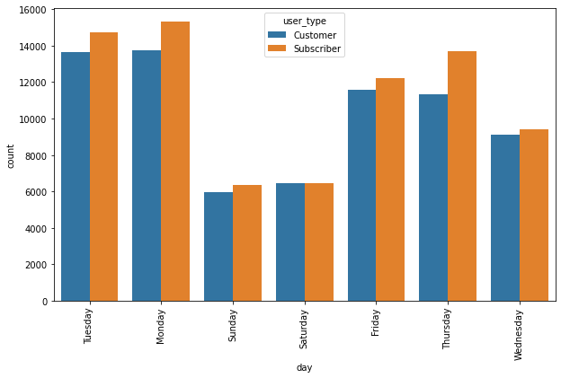

```python
plt.figure(figsize=(10,6))
sns.countplot(data = df_dec, x ='day', hue = "user_type");
plt.xticks(rotation=90);
```

From the above data it looks like number of customers using ride service is more than that of subscribers in week before christmas.

### Now lets look at the average and median travel duration by month

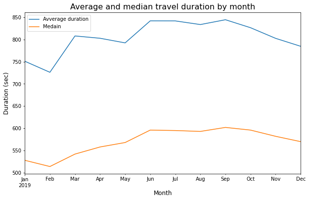

```python
plt.figure(figsize=(10,6))
monthly_mean = df.set_index('start_time').resample('M')['duration_sec'].mean()
monthly_mean.plot();
monthly_mode = df.set_index('start_time').resample('M')['duration_sec'].median()
monthly_mode.plot();
plt.xlabel('Month', fontsize=12)
plt.ylabel('Duration (sec)', fontsize=12)
plt.title('Average and median travel duration by month', fontsize=16)
plt.legend(['Avverage duration','Medain'])
```

### Lets look at the trip duration by different user types

```python
y_co = df.duration_sec/60
```

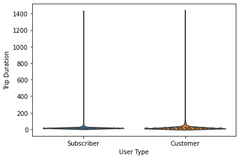

```python
sns.violinplot(data=df, x='user_type', y=y_co,inner='quartile');
plt.xlabel('User Type');
plt.ylabel('Trip Duration');
```

Since almost more than 95% of the peope used rentals for less than 30 mins let modify our graph to display the same.

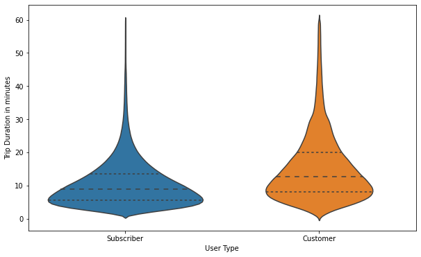

```python
plt.figure(figsize=(10,6))
df1 = df[df.duration_sec < 3600]
sns.violinplot(data = df1, x='user_type', y=df.duration_sec/60 ,inner='quartile');
plt.xlabel('User Type');
plt.ylabel('Trip Duration in minutes');
```

So the average trip duration of Subcriber is less than that of the customer. This might be because subscribers are using it commute to work wile customers might use it roam around or they might be some tourist.

## Multivariate Exploration

### let see how trip duration varies between different user types.

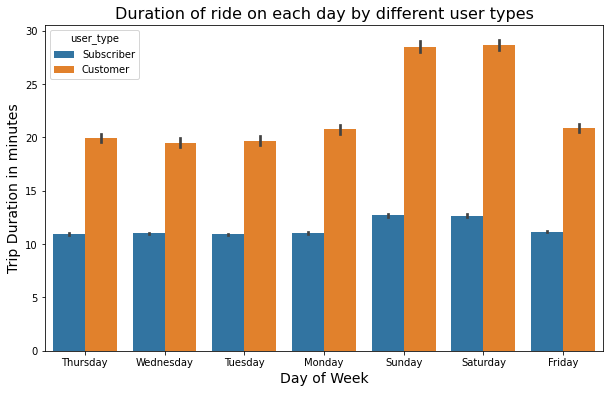

```python
plt.figure(figsize=(10,6))
sns.barplot(data=df, x='day', y=y_co, hue='user_type');
plt.xlabel('Day of Week', fontsize=14);
plt.ylabel('Trip Duration in minutes', fontsize=14);
plt.title('Duration of ride on each day by different user types', fontsize=16)
```

We can see that avg trip duration for customers is more than that of subscriber even though the number of subscribers taking the rides are more as we saw in earlier graphs. So we can confiidently say that most of the subscribers are using the rental service as theire vehicle for commute and other customers are mostly using it for roaming or to go from one place to another.

### will create a pairplot to see if there are any more interesting relationships we can find using our data

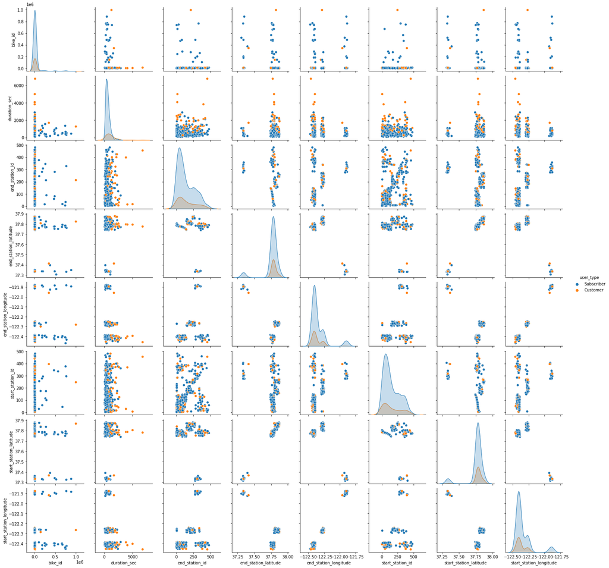

```python
sns.pairplot(df.sample(500), hue = 'user_type');
```

This data from above graph doesn't really show any interestng patterns other than we already know.

### Were there any interesting or surprising interactions between features?

The most interesting interaction is in the month of december when the user type of customer have taken more rides than that of the subscribed user before the week of christmas.

```python
df.to_csv('baywheels_tripdata_2019_clean.csv', index = False)
```

References :  
geeksforgeeks : https://www.geeksforgeeks.org/python-pandas-dataframe-resample/  
analyticsvidhya : https://www.analyticsvidhya.com/blog/2020/05/datetime-variables-python-pandas/